# Customer Segmentation

### Reg. No: 20BCE1802

### Name:Pragnya Prakash Panda

## Setup

```r
Mall_Customers <- read.csv("C:/Users/hp/OneDrive/Desktop/DATA ANALYTICS JCOMP/Mall_Customers.csv")
library(dplyr)
library(lubridate)
```

## What problem are you trying to solve?

we are trying to help compines to deploy customer segmentation. Customer Segmentation is the process of division of customer base into several groups of individuals that share a similarity in different ways that are relevant to marketing such as gender, age, interests, and miscellaneous spending habits.

## What data have you chosen?(Chosen Dataset, Source of dataset, Description of dataset, basic commands to describe dataset)

```r
(Mall_Customers)
```

```
##     CustomerID Gender Age Annual.Income..k.. Spending.Score..1.100.
## 1            1   Male  19                 15                     39
## 2            2   Male  21                 15                     81
## 3            3 Female  20                 16                      6
## 4            4 Female  23                 16                     77
## 5            5 Female  31                 17                     40
## 6            6 Female  22                 17                     76
## 7            7 Female  35                 18                      6
## 8            8 Female  23                 18                     94
## 9            9   Male  64                 19                      3
## 10          10 Female  30                 19                     72
## 11          11   Male  67                 19                     14
## 12          12 Female  35                 19                     99
## 13          13 Female  58                 20                     15
## 14          14 Female  24                 20                     77
```

[output cut: 789 more lines]

```r
str(Mall_Customers)
```

```
## 'data.frame':    200 obs. of  22 variables:
##  $ CustomerID             : int  1 2 3 4 5 6 7 8 9 10 ...
##  $ Gender                 : chr  "Male" "Male" "Female" "Female" ...
##  $ Age                    : int  19 21 20 23 31 22 35 23 64 30 ...
##  $ Annual.Income..k..     : int  15 15 16 16 17 17 18 18 19 19 ...
##  $ Spending.Score..1.100. : int  39 81 6 77 40 76 6 94 3 72 ...
##  $ Number.of.items.bought : int  15 15 16 16 17 17 18 18 19 19 ...
##  $ Invoice.ID             : chr  "750-67-8428" "226-31-3081" "631-41-3108" "123-19-1176" ...
##  $ Branch                 : chr  "A" "C" "A" "A" ...
##  $ City                   : chr  "Yangon" "Naypyitaw" "Yangon" "Yangon" ...
##  $ Customer.type          : chr  "Member" "Normal" "Normal" "Member" ...
##  $ Product.line           : chr  "Health and beauty" "Electronic accessories" "Home and lifestyle" "Health and beauty" ...
##  $ Unit.price             : num  74.7 15.3 46.3 58.2 86.3 ...
##  $ Quantity               : int  7 5 7 8 7 7 6 10 2 3 ...
##  $ Tax.5.                 : num  26.14 3.82 16.22 23.29 30.21 ...
##  $ Total                  : num  549 80.2 340.5 489 634.4 ...
##  $ Date                   : chr  "1/5/2019" "3/8/2019" "3/3/2019" "1/27/2019" ...
##  $ Time                   : chr  "13:08" "10:29" "13:23" "20:33" ...
##  $ Payment                : chr  "Ewallet" "Cash" "Credit card" "Ewallet" ...
##  $ cogs                   : num  522.8 76.4 324.3 465.8 604.2 ...
##  $ gross.margin.percentage: num  4.76 4.76 4.76 4.76 4.76 ...
##  $ gross.income           : num  26.14 3.82 16.22 23.29 30.21 ...
##  $ Rating                 : num  9.1 9.6 7.4 8.4 5.3 4.1 5.8 8 7.2 5.9 ...
```

```r
names(Mall_Customers)
```

```
##  [1] "CustomerID"              "Gender"
##  [3] "Age"                     "Annual.Income..k.."
##  [5] "Spending.Score..1.100."  "Number.of.items.bought"
##  [7] "Invoice.ID"              "Branch"
##  [9] "City"                    "Customer.type"
## [11] "Product.line"            "Unit.price"
## [13] "Quantity"                "Tax.5."
## [15] "Total"                   "Date"
## [17] "Time"                    "Payment"
## [19] "cogs"                    "gross.margin.percentage"
## [21] "gross.income"            "Rating"
```

```r
dim(Mall_Customers)
```

```
## [1] 200  22
```

```r
head(Mall_Customers)
```

```
##   CustomerID Gender Age Annual.Income..k.. Spending.Score..1.100.
## 1          1   Male  19                 15                     39
## 2          2   Male  21                 15                     81
## 3          3 Female  20                 16                      6
## 4          4 Female  23                 16                     77
## 5          5 Female  31                 17                     40
## 6          6 Female  22                 17                     76
##   Number.of.items.bought  Invoice.ID Branch      City Customer.type
## 1                     15 750-67-8428      A    Yangon        Member
## 2                     15 226-31-3081      C Naypyitaw        Normal
## 3                     16 631-41-3108      A    Yangon        Normal
## 4                     16 123-19-1176      A    Yangon        Member
## 5                     17 373-73-7910      A    Yangon        Normal
## 6                     17 699-14-3026      C Naypyitaw        Normal
##             Product.line Unit.price Quantity  Tax.5.    Total      Date  Time
## 1      Health and beauty      74.69        7 26.1415 548.9715  1/5/2019 13:08
## 2 Electronic accessories      15.28        5  3.8200  80.2200  3/8/2019 10:29
## 3     Home and lifestyle      46.33        7 16.2155 340.5255  3/3/2019 13:23
## 4      Health and beauty      58.22        8 23.2880 489.0480 1/27/2019 20:33
## 5      Sports and travel      86.31        7 30.2085 634.3785  2/8/2019 10:37
## 6 Electronic accessories      85.39        7 29.8865 627.6165 3/25/2019 18:30
##       Payment   cogs gross.margin.percentage gross.income Rating
## 1     Ewallet 522.83                4.761905      26.1415    9.1
## 2        Cash  76.40                4.761905       3.8200    9.6
## 3 Credit card 324.31                4.761905      16.2155    7.4
## 4     Ewallet 465.76                4.761905      23.2880    8.4
## 5     Ewallet 604.17                4.761905      30.2085    5.3
## 6     Ewallet 597.73                4.761905      29.8865    4.1
```

```r
summary(Mall_Customers)
```

```
##    CustomerID        Gender               Age        Annual.Income..k..
##  Min.   :  1.00   Length:200         Min.   :18.00   Min.   : 15.00
##  1st Qu.: 50.75   Class :character   1st Qu.:28.75   1st Qu.: 41.50
##  Median :100.50   Mode  :character   Median :36.00   Median : 61.50
##  Mean   :100.50                      Mean   :38.85   Mean   : 60.56
##  3rd Qu.:150.25                      3rd Qu.:49.00   3rd Qu.: 78.00
##  Max.   :200.00                      Max.   :70.00   Max.   :137.00
##  Spending.Score..1.100. Number.of.items.bought  Invoice.ID
##  Min.   : 1.00          Min.   : 15.00         Length:200
##  1st Qu.:34.75          1st Qu.: 41.50         Class :character
##  Median :50.00          Median : 61.50         Mode  :character
##  Mean   :50.20          Mean   : 60.56
##  3rd Qu.:73.00          3rd Qu.: 78.00
##  Max.   :99.00          Max.   :137.00
##     Branch              City           Customer.type      Product.line
##  Length:200         Length:200         Length:200         Length:200
##  Class :character   Class :character   Class :character   Class :character
##  Mode  :character   Mode  :character   Mode  :character   Mode  :character
##
##
##
##    Unit.price       Quantity          Tax.5.            Total
##  Min.   :10.96   Min.   : 1.000   Min.   : 0.7715   Min.   :  16.2
##  1st Qu.:34.23   1st Qu.: 4.000   1st Qu.: 7.8464   1st Qu.: 164.8
##  Median :58.24   Median : 6.000   Median :15.3860   Median : 323.1
##  Mean   :58.44   Mean   : 6.055   Mean   :17.9922   Mean   : 377.8
##  3rd Qu.:82.14   3rd Qu.: 8.000   3rd Qu.:26.1340   3rd Qu.: 548.8
##  Max.   :99.96   Max.   :10.000   Max.   :49.4900   Max.   :1039.3
##      Date               Time             Payment               cogs
##  Length:200         Length:200         Length:200         Min.   : 15.43
##  Class :character   Class :character   Class :character   1st Qu.:156.93
##  Mode  :character   Mode  :character   Mode  :character   Median :307.72
##                                                           Mean   :359.84
##                                                           3rd Qu.:522.68
##                                                           Max.   :989.80
##  gross.margin.percentage  gross.income         Rating
##  Min.   :4.762           Min.   : 0.7715   Min.   : 4.000
##  1st Qu.:4.762           1st Qu.: 7.8464   1st Qu.: 5.675
##  Median :4.762           Median :15.3860   Median : 7.100
##  Mean   :4.762           Mean   :17.9922   Mean   : 7.017
##  3rd Qu.:4.762           3rd Qu.:26.1340   3rd Qu.: 8.400
##  Max.   :4.762           Max.   :49.4900   Max.   :10.000
```

## Frame your objectives

### Customer Gender Visualization

In this, we will create a barplot and a piechart to show the gender distribution across our customer_data dataset.

### Analysis of the Annual Income of the Customers

In this section of the R project, we will create visualizations to analyze the annual income of the customers. We will plot a histogram and then we will proceed to examine this data using a density plot.

### Visualization of Age Distribution

### Analyzing Spending Score of the Customers

### Determining Optimal Clusters

### K-means clustering

We specify the number of clusters that we need to create. The algorithm selects k objects at random from the dataset. This object is the initial cluster or mean. The closest centroid obtains the assignment of a new observation. We base this assignment on the Euclidean Distance between object and the centroid. k clusters in the data points update the centroid through calculation of the new mean values present in all the data points of the cluster. The kth cluster’s centroid has a length of p that contains means of all variables for observations in the k-th cluster. We denote the number of variables with p. Iterative minimization of the total within the sum of squares. Then through the iterative minimization of the total sum of the square, the assignment stop wavering when we achieve maximum iteration. The default value is 10 that the R software uses for the maximum iterations.

## Review-2

*Customer Analysis*

### Customer Gender Visualization

In this, we will create a barplot and a piechart to show the gender distribution across our customer_data dataset.

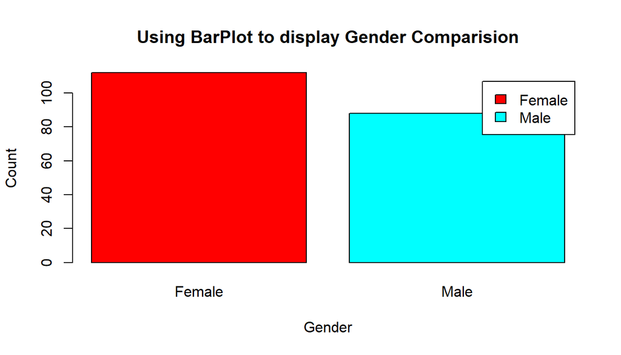

```r
a=table(Mall_Customers$Gender)
barplot(a,main="Using BarPlot to display Gender Comparision",
       ylab="Count",
       xlab="Gender",
       col=rainbow(2),
       legend=rownames(a))
```

From the above barplot, we observe that the number of females is higher than the males. Now, let us visualize a pie chart to observe the ratio of male and female distribution. (Learnt from online “plotrix library”)

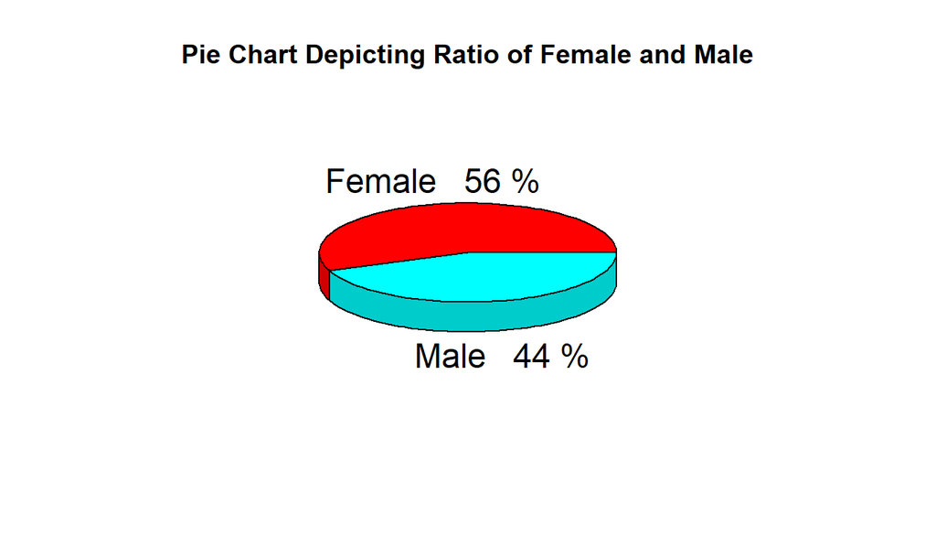

```r
pct=round(a/sum(a)*100)
lbs=paste(c("Female","Male")," ",pct,"%",sep=" ")
library(plotrix)
pie3D(a,labels=lbs,
   main="Pie Chart Depicting Ratio of Female and Male")
```

### Visualization of Age Distribution

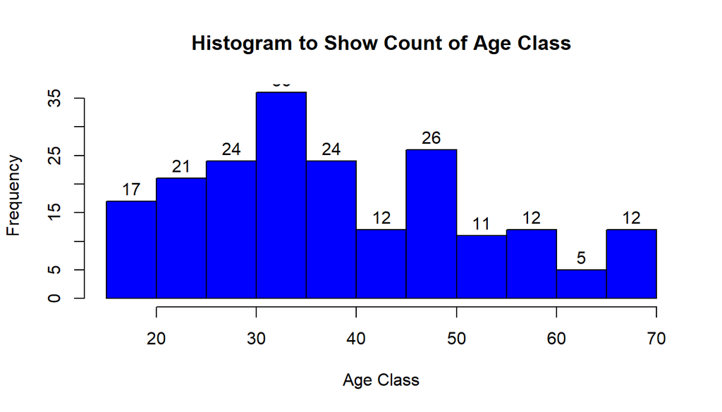

```r
hist(Mall_Customers$Age,
    col="blue",
    main="Histogram to Show Count of Age Class",
    xlab="Age Class",
    ylab="Frequency",
    labels=TRUE)
```

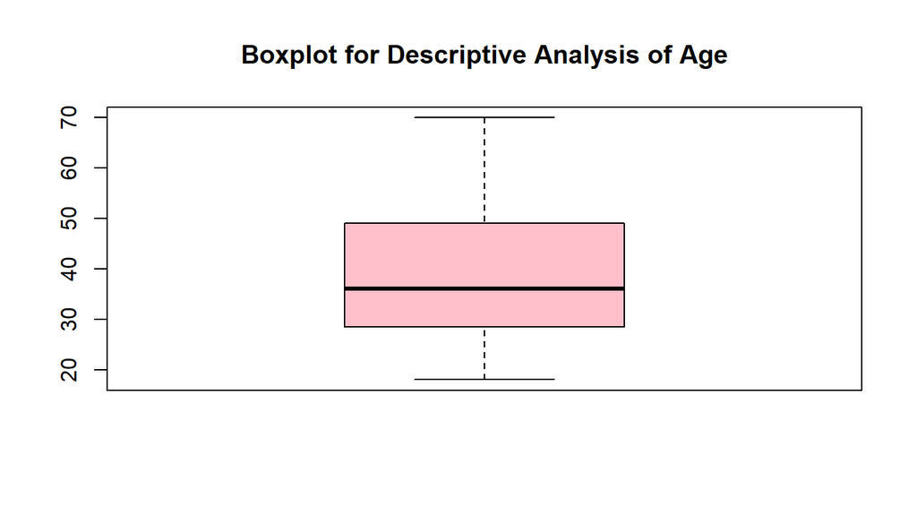

```r
boxplot(Mall_Customers$Age,
       col="pink",
       main="Boxplot for Descriptive Analysis of Age")
```

From the above two visualizations, we conclude that the maximum customer ages are between 30 and 35. The minimum age of customers is 18, whereas, the maximum age is 70.

### Analysis of the Annual Income of the Customers

In this section of the R project, we will create visualizations to analyze the annual income of the customers. We will plot a histogram and then we will proceed to examine this data using a density plot.

```r
summary(Mall_Customers$Annual.Income..k..)
```

```
##    Min. 1st Qu.  Median    Mean 3rd Qu.    Max.
##   15.00   41.50   61.50   60.56   78.00  137.00
```

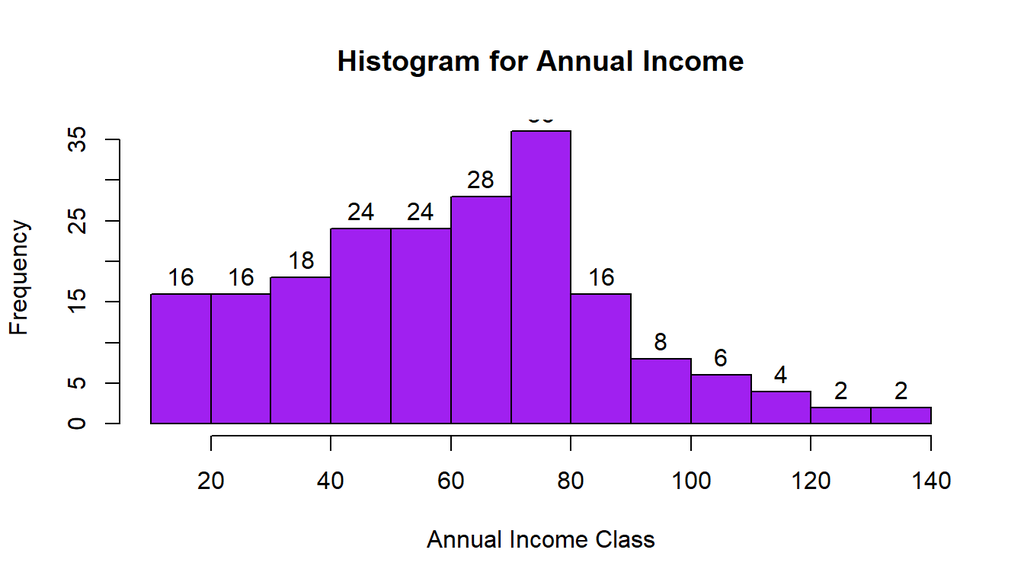

```r
hist(Mall_Customers$Annual.Income..k..,
  col="purple",
  main="Histogram for Annual Income",
  xlab="Annual Income Class",
  ylab="Frequency",
  labels=TRUE)
```

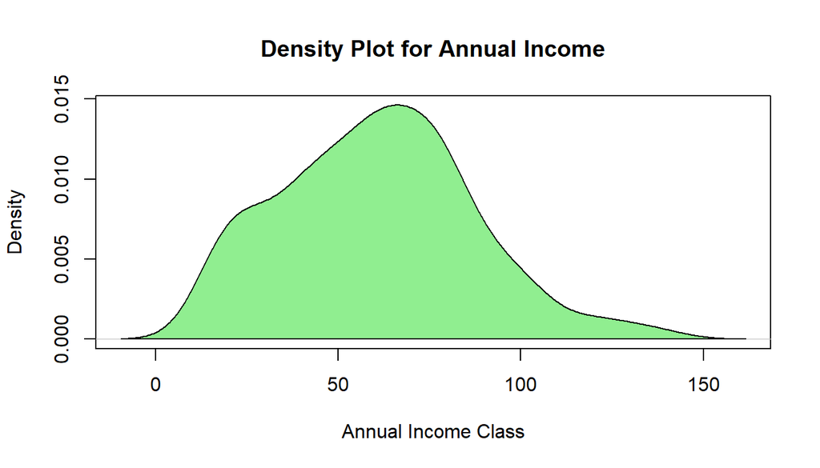

```r
plot(density(Mall_Customers$Annual.Income..k..),
    col="yellow",
    main="Density Plot for Annual Income",
    xlab="Annual Income Class",
    ylab="Density")
polygon(density(Mall_Customers$Annual.Income..k..),
        col="lightgreen")
```

From the above descriptive analysis, we conclude that the minimum annual income of the customers is 15 and the maximum income is 137. People earning an average income of 70 have the highest frequency count in our histogram distribution. The average salary of all the customers is 60.56.

### Analyzing Spending Score of the Customers

```r
summary(Mall_Customers$Spending.Score..1.100.)
```

```
##    Min. 1st Qu.  Median    Mean 3rd Qu.    Max.
##    1.00   34.75   50.00   50.20   73.00   99.00
```

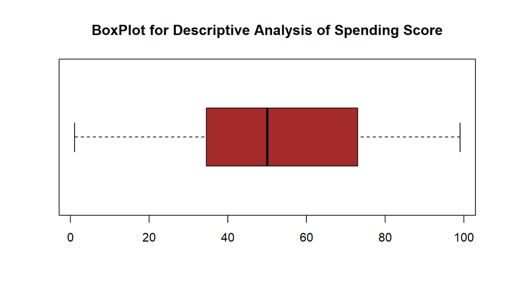

```r
boxplot(Mall_Customers$Spending.Score..1.100.,
   horizontal=TRUE,
   col="brown",
   main="BoxPlot for Descriptive Analysis of Spending Score")
```

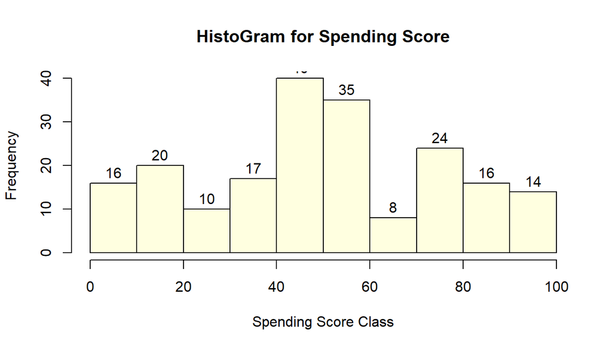

```r
hist(Mall_Customers$Spending.Score..1.100.,
    main="HistoGram for Spending Score",
    xlab="Spending Score Class",
    ylab="Frequency",
    col="lightyellow",
    labels=TRUE)
```

*Product Analyzing*

```r
retail<-Mall_Customers
```

```r
retail$Date <- gsub('/', '-', retail$Date)

r2 <- retail %>%
  mutate(DATE=mdy(Date))%>%
  select(everything())




retailA<- filter(r2, Branch=='A')
retailB<- filter(r2, Branch=='B')
retailC<- filter(r2, Branch=='C')

retailAsum <- group_by(retailA, DATE, Product.line) %>% select(everything())
retailAsum<- summarise(retailAsum, daytotal=sum(Total)) %>% select(everything())
retailBsum <- group_by(retailB, DATE, Product.line) %>% select(everything())
retailBsum<- summarise(retailBsum, daytotal=sum(Total)) %>% select(everything())
```

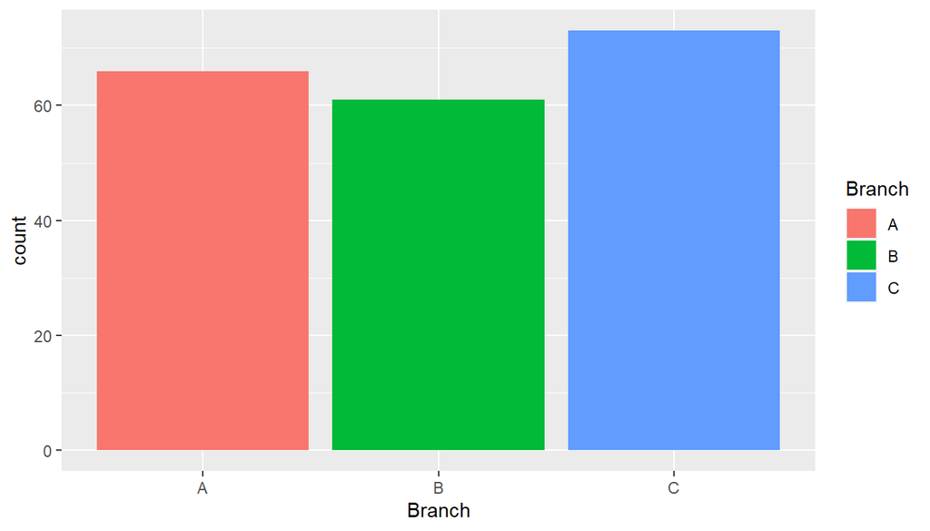

```r
library(ggplot2)
ggplot (data=retail)+
  geom_bar(mapping=aes(x=Branch,fill=Branch))
```

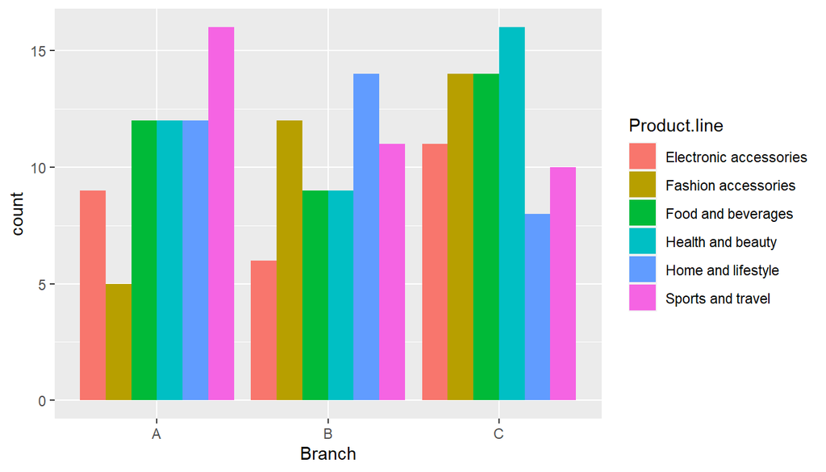

```r
ggplot (data=retail)+
  geom_bar(mapping=aes(x=Branch, fill=Product.line), position="dodge")
```

This graph shows quantity of sales per category. It appears that each store has a certain category that they sell more of than the other stores. This would benefit from futher analysis in order to determine the cause, e.g if the customer needs are different or if perhaps the products are not being displayed in an efficient manner.

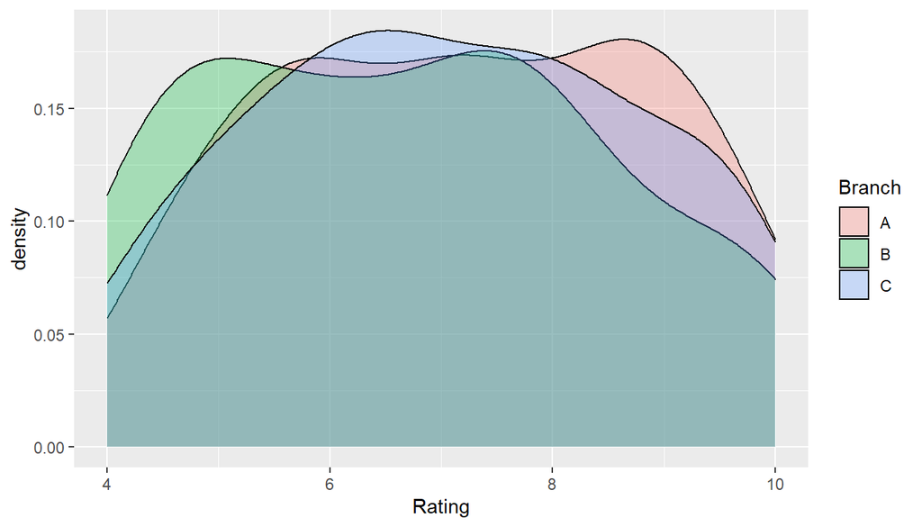

```r
ggplot(data=retail) +
    geom_density(mapping=aes(x=Rating, fill=Branch), alpha=.3)
```

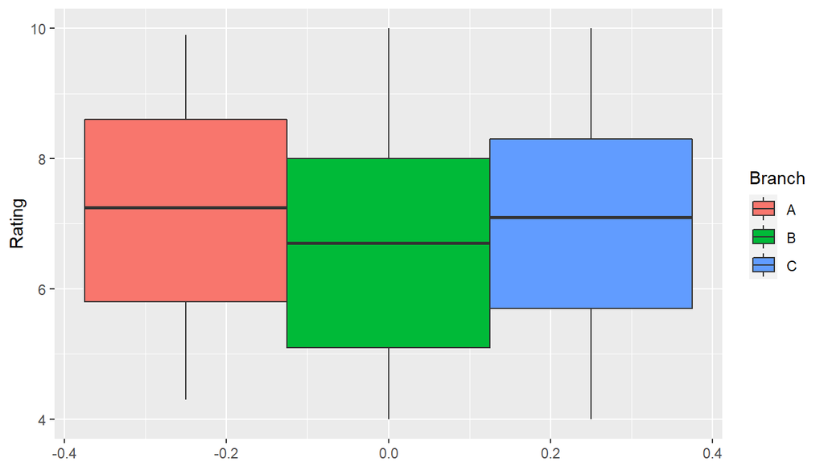

```r
ggplot (data=retail)+
  geom_boxplot(mapping=aes(x=Rating, fill=Branch), position="dodge")+
    coord_flip()
```

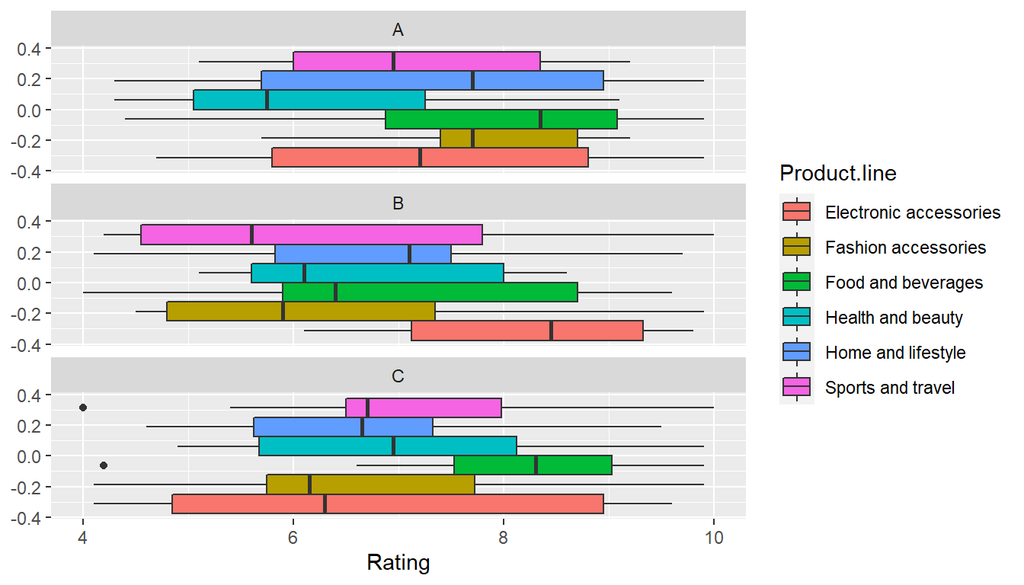

```r
ggplot (data=retail)+
  geom_boxplot(mapping=aes(x=Rating, fill=Product.line), position="dodge")+
    facet_wrap(~Branch, nrow=3)
```

The first graph shows the distribution of the ratings per branch The second is a boxplot representing the statistical summary of the branch The third is a boxplot representing the ratings per product line by branch

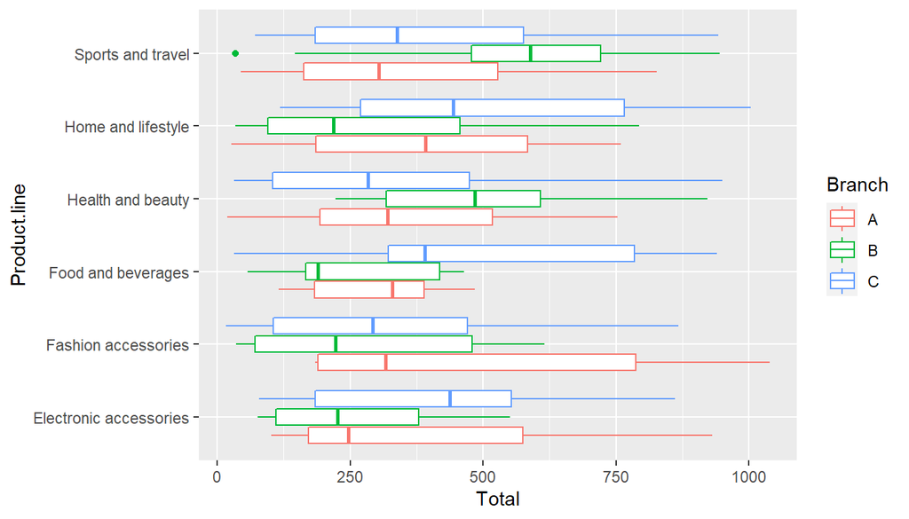

```r
ggplot(data=retail, mapping=aes(x=Product.line, y=Total, color=Branch))+
  geom_boxplot()+
  coord_flip()
```

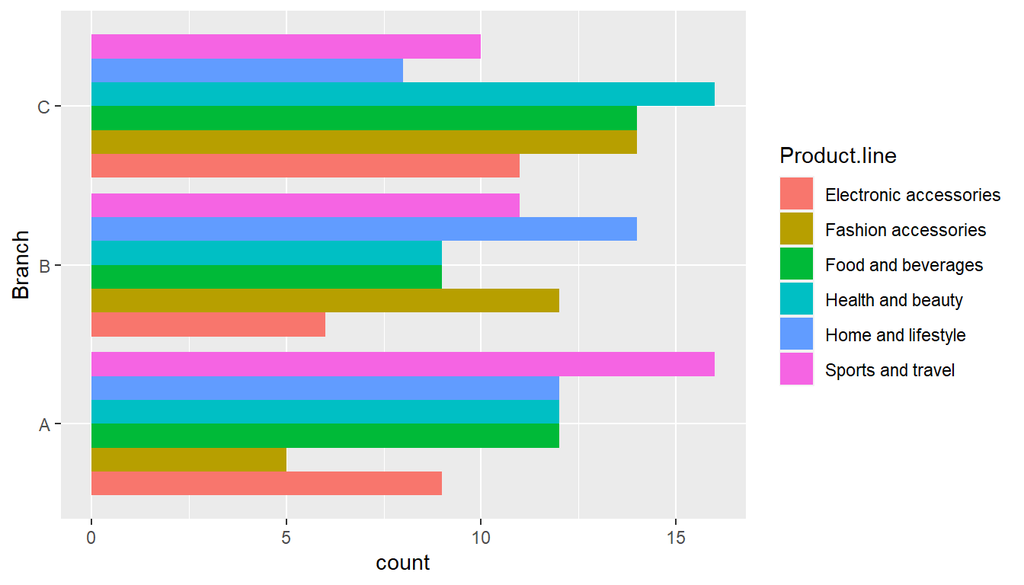

```r
ggplot (data=retail)+
  geom_bar(mapping=aes(x=Branch, fill=Product.line), position="dodge") +
    coord_flip()
```

The first graph shows the range of sales totals based on the category, the second graph is like the second graph above except flipped for easier comparison

More analysis is needed but perhaps this store would benefit by removing slow moving products, such as family oriented value size packs, and replacing them with products from a better performing category

The next analyses we will do will be based on each store over time. However, the data is not in a useable format yet. We need to divide the dataset up by store as well as transform the date data into a universal format. We will also aggregate the data based on total sales per day per product line

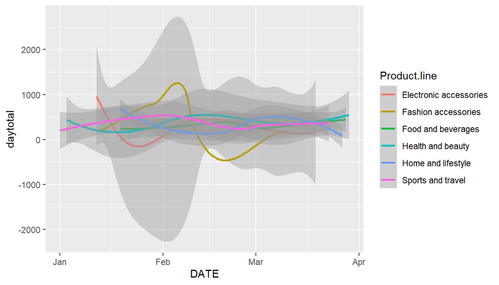

```r
ggplot(data=retailAsum)+
    geom_smooth(mapping=aes(x=DATE, y=daytotal ,color=Product.line))
```

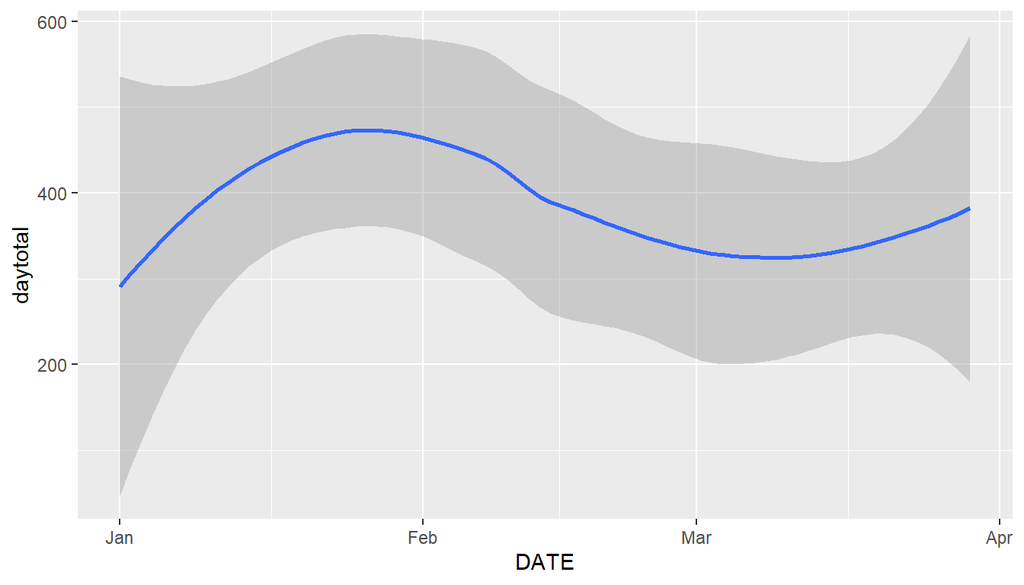

```r
ggplot(data=retailAsum)+
    geom_smooth(mapping=aes(x=DATE, y=daytotal))
```

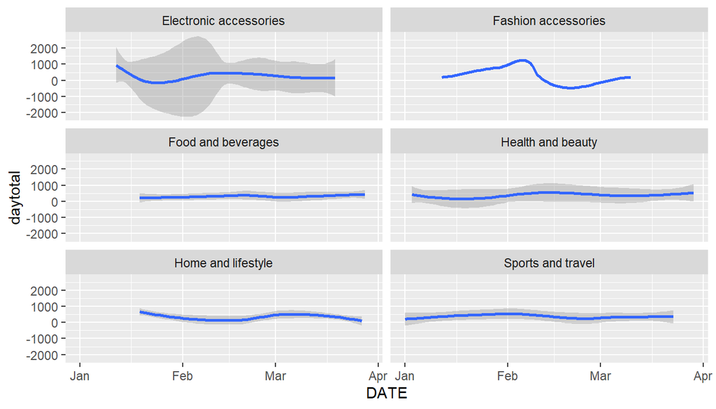

```r
ggplot(data=retailAsum) +
    geom_smooth(mapping=aes(x=DATE, y=daytotal)) +
    facet_wrap(~Product.line, nrow=3)
```

The second graph shows the trendline of the total per day for location A. It is similar to the above graph but without the categories. From it we see there is a decline in sales during Feburary, with an uptick in March.

The observations from these charts would be a great start towards creating a machine learning model to analyze sales trends vs month of year in order to create bundles, optimize high traffic displays, and in advertising.

The third chart included is just the first chart broken up. It is easier to see individual trends but more difficult to see comparative trends. Both graphs serve a purpose here

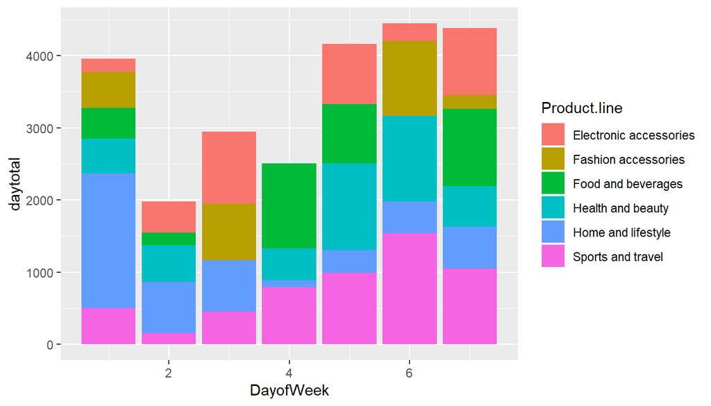

```r
retailAsum <- retailAsum %>%
  mutate(
    Month=month(DATE)
  )

retailAsum <- retailAsum %>%
  mutate(
    DayofWeek=wday(DATE)
  )

retailAsum <- retailAsum %>%
  mutate(
    DayofYear=yday(DATE)
  )


ggplot(data=retailAsum)+
    geom_bar(mapping=aes(x=DayofWeek, y=daytotal, fill=Product.line),stat='identity')
```

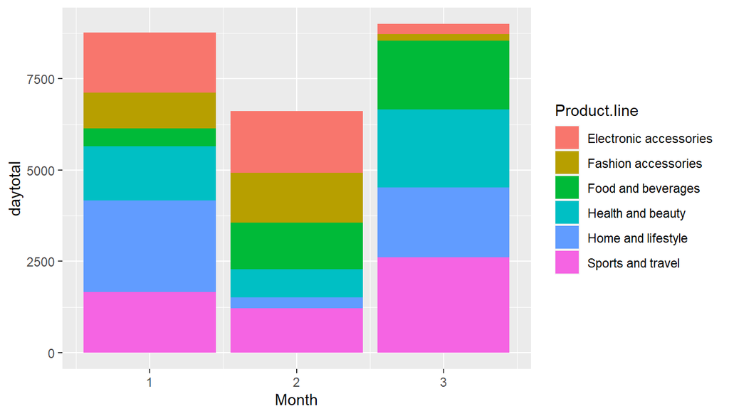

```r
ggplot(data=retailAsum)+
    geom_bar(mapping=aes(x=Month, y=daytotal, fill=Product.line),stat='identity')
```

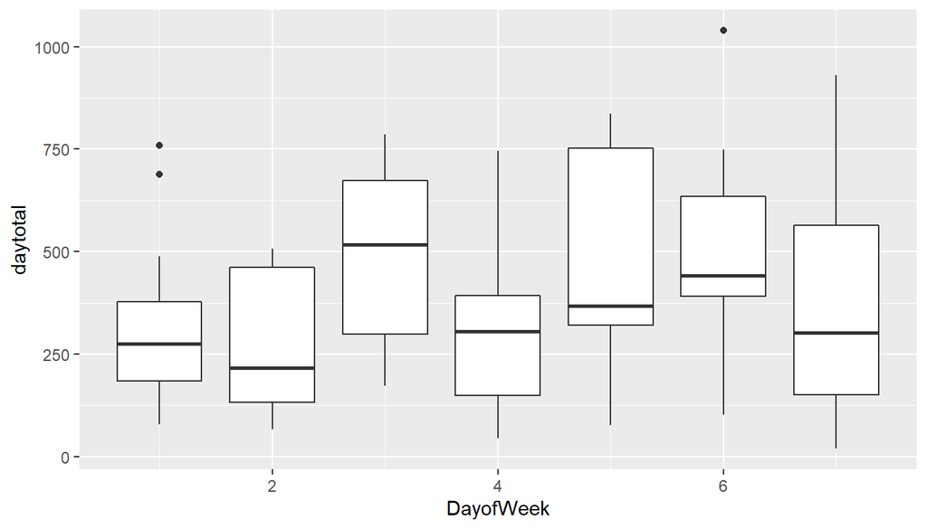

```r
ggplot(data=retailAsum)+
    geom_boxplot(mapping=aes(x=DayofWeek, y=daytotal, group=DayofWeek))
```

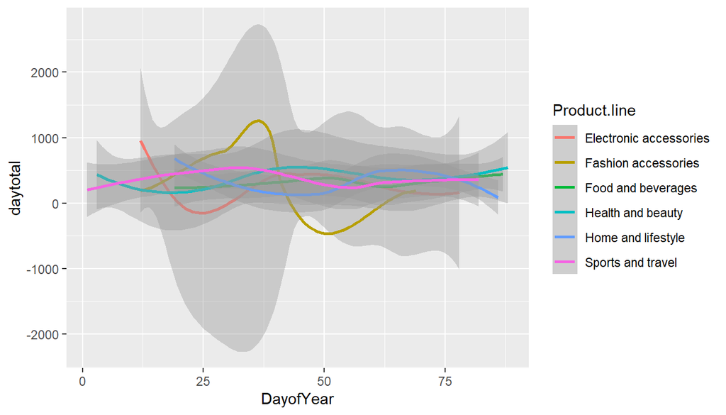

```r
ggplot(data=retailAsum)+
    geom_smooth(mapping=aes(x=DayofYear, y=daytotal, color=Product.line))
```

*K-means*

While using the k-means clustering algorithm, the first step is to indicate the number of clusters (k) that we wish to produce in the final output. The algorithm starts by selecting k objects from dataset randomly that will serve as the initial centers for our clusters. These selected objects are the cluster means, also known as centroids. Then, the remaining objects have an assignment of the closest centroid. This centroid is defined by the Euclidean Distance present between the object and the cluster mean. We refer to this step as “cluster assignment”. When the assignment is complete, the algorithm proceeds to calculate new mean value of each cluster present in the data. After the recalculation of the centers, the observations are checked if they are closer to a different cluster. Using the updated cluster mean, the objects undergo reassignment. This goes on repeatedly through several iterations until the cluster assignments stop altering. The clusters that are present in the current iteration are the same as the ones obtained in the previous iteration.

Summing up the K-means clustering –

We specify the number of clusters that we need to create. The algorithm selects k objects at random from the dataset. This object is the initial cluster or mean. The closest centroid obtains the assignment of a new observation. We base this assignment on the Euclidean Distance between object and the centroid. k clusters in the data points update the centroid through calculation of the new mean values present in all the data points of the cluster. The kth cluster’s centroid has a length of p that contains means of all variables for observations in the k-th cluster. We denote the number of variables with p. Iterative minimization of the total within the sum of squares. Then through the iterative minimization of the total sum of the square, the assignment stop wavering when we achieve maximum iteration. The default value is 10 that the R software uses for the maximum iterations. Determining Optimal Clusters While working with clusters, you need to specify the number of clusters to use. You would like to utilize the optimal number of clusters. To help you in determining the optimal clusters, there are three popular methods –

Elbow method Silhouette method Gap statistic

#### Elbow Method

The main goal behind cluster partitioning methods like k-means is to define the clusters such that the intra-cluster variation stays minimum.

minimize(sum W(Ck)), k=1…k

Where Ck represents the kth cluster and W(Ck) denotes the intra-cluster variation. With the measurement of the total intra-cluster variation, one can evaluate the compactness of the clustering boundary. We can then proceed to define the optimal clusters as follows –

First, we calculate the clustering algorithm for several values of k. This can be done by creating a variation within k from 1 to 10 clusters. We then calculate the total intra-cluster sum of square (iss). Then, we proceed to plot iss based on the number of k clusters. This plot denotes the appropriate number of clusters required in our model. In the plot, the location of a bend or a knee is the indication of the optimum number of clusters.

```r
library(purrr)
set.seed(123)
k1 = kmeans(Mall_Customers[,3:5],10,iter.max=100,nstart=100,algorithm="Lloyd")
k1
```

```
## K-means clustering with 10 clusters of sizes 22, 13, 12, 10, 29, 27, 29, 11, 25, 22
##
## Cluster means:
##         Age Annual.Income..k.. Spending.Score..1.100.
## 1  25.27273           25.72727              79.363636
## 2  38.23077           30.38462              35.076923
## 3  48.75000           24.58333               9.583333
## 4  32.20000          109.70000              82.000000
## 5  32.86207           78.55172              82.172414
## 6  61.44444           51.18519              50.444444
## 7  24.44828           56.37931              50.724138
## 8  42.63636          108.18182              21.272727
## 9  46.16000           61.32000              46.360000
## 10 39.36364           79.13636              13.363636
##
## Clustering vector:
##   [1]  2  1  3  1  2  1  3  1  3  1  3  1  3  1  3  1  2  1  2  1  2  1  3  1  3
##  [26]  1  2  1  2  1  3  1  3  1  3  1  3  1  2  1  6  1  2  7  2  1  6  7  2  2
##  [51]  6  7  7  6  6  2  6  6  7  6  6  7  6  6  6  7  9  6  7  7  6  9  6  6  6
##  [76]  7  9  9  7  9  6  9  6  9  7  9  6  7  7  9  6  7  9  9  7  7  9  7  9  7
## [101]  7  9  6  7  9  7  6  9  6  6  6  7  9  7  7  7  6  9  9  9  7  9  9  5 10
## [126]  5  9  5 10  5 10  5  7  5 10  5 10  5 10  5 10  5  7  5 10  5  9  5 10  5
## [151] 10  5 10  5 10  5 10  5 10  5  9  5 10  5 10  5 10  5 10  5 10  5 10  5 10
## [176]  5 10  5  8  5  8  4  8  4  8  4  8  4  8  4  8  4  8  4  8  4  8  4  8  4
##
## Within cluster sum of squares by cluster:
##  [1] 4099.818 2622.308 2830.083 2605.700 4148.759 3909.407 4661.793 3520.364
##  [9] 3278.560 5416.773
##  (between_SS / total_SS =  88.0 %)
##
## Available components:
##
## [1] "cluster"      "centers"      "totss"        "withinss"     "tot.withinss"
## [6] "betweenss"    "size"         "iter"         "ifault"
```

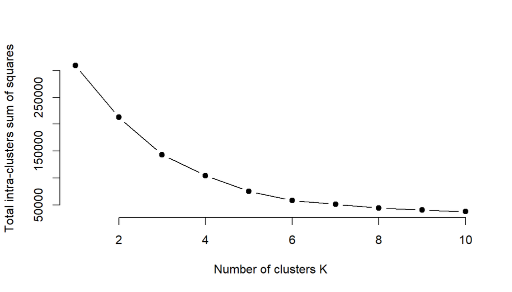

```r
# function to calculate total intra-cluster sum of square
iss <- function(k) {
  kmeans(Mall_Customers[,3:5],k,iter.max=100,nstart=100,algorithm="Lloyd" )$tot.withinss
}
k.values <- 1:10
iss_values <- map_dbl(k.values, iss)
plot(k.values, iss_values,
    type="b", pch = 19, frame = FALSE,
    xlab="Number of clusters K",
    ylab="Total intra-clusters sum of squares")
```

### Average Silhouette Method

With the help of the average silhouette method, we can measure the quality of our clustering operation. With this, we can determine how well within the cluster is the data object. If we obtain a high average silhouette width, it means that we have good clustering. The average silhouette method calculates the mean of silhouette observations for different k values. With the optimal number of k clusters, one can maximize the average silhouette over significant values for k clusters.

Using the silhouette function in the cluster package, we can compute the average silhouette width using the kmean function. Here, the optimal cluster will possess highest average.

```r
library(cluster)
library(gridExtra)
library(grid)
k2<-kmeans(Mall_Customers[,3:5],2,iter.max=100,nstart=50,algorithm="Lloyd")
k2
```

```
## K-means clustering with 2 clusters of sizes 85, 115
##
## Cluster means:
##        Age Annual.Income..k.. Spending.Score..1.100.
## 1 28.95294           62.17647               73.62353
## 2 46.16522           59.36522               32.88696
##
## Clustering vector:
##   [1] 2 1 2 1 2 1 2 1 2 1 2 1 2 1 2 1 2 1 2 1 2 1 2 1 2 1 2 1 2 1 2 1 2 1 2 1 2
##  [38] 1 2 1 2 1 2 1 2 1 2 2 2 2 2 1 1 2 2 2 2 2 1 2 2 1 2 2 2 1 2 2 1 2 2 2 2 2
##  [75] 2 1 2 2 1 2 2 1 2 2 1 2 2 1 1 2 2 2 2 2 2 1 2 1 2 1 2 2 2 1 2 2 2 2 2 2 2
## [112] 1 2 1 1 1 2 1 2 2 1 2 1 1 2 1 2 1 2 1 2 1 2 1 2 1 2 1 2 1 2 1 2 1 2 1 2 1
## [149] 2 1 2 1 2 1 2 1 2 1 2 1 2 1 2 1 2 1 2 1 2 1 2 1 2 1 2 1 2 1 2 1 2 1 2 1 2
## [186] 1 2 1 2 1 2 1 2 1 2 1 2 1 2 1
##
## Within cluster sum of squares by cluster:
## [1]  88300.12 124540.05
##  (between_SS / total_SS =  31.1 %)
##
## Available components:
##
## [1] "cluster"      "centers"      "totss"        "withinss"     "tot.withinss"
## [6] "betweenss"    "size"         "iter"         "ifault"
```

[figure not shown]

```r
s2<-plot(silhouette(k2$cluster,dist(Mall_Customers[,3:5],"euclidean",)),col = "red")
```

```r
k3<-kmeans(Mall_Customers[,3:5],3,iter.max=100,nstart=50,algorithm="Lloyd")
k3
```

```
## K-means clustering with 3 clusters of sizes 38, 123, 39
##
## Cluster means:
##        Age Annual.Income..k.. Spending.Score..1.100.
## 1 40.39474           87.00000               18.63158
## 2 40.32520           44.15447               49.82927
## 3 32.69231           86.53846               82.12821
##
## Clustering vector:
##   [1] 2 2 2 2 2 2 2 2 2 2 2 2 2 2 2 2 2 2 2 2 2 2 2 2 2 2 2 2 2 2 2 2 2 2 2 2 2
##  [38] 2 2 2 2 2 2 2 2 2 2 2 2 2 2 2 2 2 2 2 2 2 2 2 2 2 2 2 2 2 2 2 2 2 2 2 2 2
##  [75] 2 2 2 2 2 2 2 2 2 2 2 2 2 2 2 2 2 2 2 2 2 2 2 2 2 2 2 2 2 2 2 2 2 2 2 2 2
## [112] 2 2 2 2 2 2 2 2 2 2 2 2 3 1 3 1 3 1 3 1 3 1 3 1 3 1 3 1 3 1 3 1 3 1 3 1 3
## [149] 1 3 1 3 1 3 1 3 1 3 1 3 1 3 1 3 1 3 1 3 1 3 1 3 1 3 1 3 1 3 1 3 1 3 1 3 1
## [186] 3 1 3 1 3 1 3 1 3 1 3 1 3 1 3
##
## Within cluster sum of squares by cluster:
## [1]  18993.92 110376.47  13972.36
##  (between_SS / total_SS =  53.6 %)
##
## Available components:
##
## [1] "cluster"      "centers"      "totss"        "withinss"     "tot.withinss"
## [6] "betweenss"    "size"         "iter"         "ifault"
```

[figure not shown]

```r
s3<-plot(silhouette(k3$cluster,dist(Mall_Customers[,3:5],"euclidean")),col = "blue")
```

```r
k4<-kmeans(Mall_Customers[,3:5],4,iter.max=100,nstart=50,algorithm="Lloyd")
k4
```

```
## K-means clustering with 4 clusters of sizes 39, 38, 28, 95
##
## Cluster means:
##        Age Annual.Income..k.. Spending.Score..1.100.
## 1 32.69231           86.53846               82.12821
## 2 40.39474           87.00000               18.63158
## 3 24.82143           28.71429               74.25000
## 4 44.89474           48.70526               42.63158
##
## Clustering vector:
##   [1] 3 3 4 3 4 3 4 3 4 3 4 3 4 3 4 3 4 3 4 3 4 3 4 3 4 3 4 3 4 3 4 3 4 3 4 3 4
##  [38] 3 4 3 4 3 4 3 4 3 4 4 4 4 4 3 4 4 4 4 4 4 4 4 4 3 4 4 4 3 4 4 3 4 4 4 4 4
##  [75] 4 4 4 4 4 4 4 4 4 4 4 4 4 4 4 4 4 4 4 4 4 4 4 4 4 4 4 4 4 4 4 4 4 4 4 4 4
## [112] 4 4 4 4 4 4 4 4 4 4 4 4 1 2 1 2 1 2 1 2 1 2 1 2 1 2 1 2 1 2 1 2 1 2 1 2 1
## [149] 2 1 2 1 2 1 2 1 2 1 2 1 2 1 2 1 2 1 2 1 2 1 2 1 2 1 2 1 2 1 2 1 2 1 2 1 2
## [186] 1 2 1 2 1 2 1 2 1 2 1 2 1 2 1
##
## Within cluster sum of squares by cluster:
## [1] 13972.359 18993.921  9099.071 62300.800
##  (between_SS / total_SS =  66.2 %)
##
## Available components:
##
## [1] "cluster"      "centers"      "totss"        "withinss"     "tot.withinss"
## [6] "betweenss"    "size"         "iter"         "ifault"
```

[figure not shown]

```r
s4<-plot(silhouette(k4$cluster,dist(Mall_Customers[,3:5],"euclidean")),col="green")
```

```r
k5<-kmeans(Mall_Customers[,3:5],5,iter.max=100,nstart=50,algorithm="Lloyd")
k5
```

```
## K-means clustering with 5 clusters of sizes 80, 22, 23, 39, 36
##
## Cluster means:
##        Age Annual.Income..k.. Spending.Score..1.100.
## 1 42.93750           55.08750               49.71250
## 2 25.27273           25.72727               79.36364
## 3 45.21739           26.30435               20.91304
## 4 32.69231           86.53846               82.12821
## 5 40.66667           87.75000               17.58333
##
## Clustering vector:
##   [1] 3 2 3 2 3 2 3 2 3 2 3 2 3 2 3 2 3 2 3 2 3 2 3 2 3 2 3 2 3 2 3 2 3 2 3 2 3
##  [38] 2 3 2 3 2 3 1 3 2 1 1 1 1 1 1 1 1 1 1 1 1 1 1 1 1 1 1 1 1 1 1 1 1 1 1 1 1
##  [75] 1 1 1 1 1 1 1 1 1 1 1 1 1 1 1 1 1 1 1 1 1 1 1 1 1 1 1 1 1 1 1 1 1 1 1 1 1
## [112] 1 1 1 1 1 1 1 1 1 1 1 1 4 5 4 1 4 5 4 5 4 5 4 5 4 5 4 5 4 5 4 1 4 5 4 5 4
## [149] 5 4 5 4 5 4 5 4 5 4 5 4 5 4 5 4 5 4 5 4 5 4 5 4 5 4 5 4 5 4 5 4 5 4 5 4 5
## [186] 4 5 4 5 4 5 4 5 4 5 4 5 4 5 4
##
## Within cluster sum of squares by cluster:
## [1] 30673.462  4099.818  8948.609 13972.359 17669.500
##  (between_SS / total_SS =  75.6 %)
##
## Available components:
##
## [1] "cluster"      "centers"      "totss"        "withinss"     "tot.withinss"
## [6] "betweenss"    "size"         "iter"         "ifault"
```

[figure not shown]

```r
s5<-plot(silhouette(k5$cluster,dist(Mall_Customers[,3:5],"euclidean")),col="orange")
```

```r
k6<-kmeans(Mall_Customers[,3:5],6,iter.max=100,nstart=50,algorithm="Lloyd")
k6
```

```
## K-means clustering with 6 clusters of sizes 35, 38, 45, 21, 39, 22
##
## Cluster means:
##        Age Annual.Income..k.. Spending.Score..1.100.
## 1 41.68571           88.22857               17.28571
## 2 27.00000           56.65789               49.13158
## 3 56.15556           53.37778               49.08889
## 4 44.14286           25.14286               19.52381
## 5 32.69231           86.53846               82.12821
## 6 25.27273           25.72727               79.36364
##
## Clustering vector:
##   [1] 4 6 4 6 4 6 4 6 4 6 4 6 4 6 4 6 4 6 4 6 4 6 4 6 4 6 4 6 4 6 4 6 4 6 4 6 4
##  [38] 6 4 6 3 6 3 2 4 6 3 2 2 2 3 2 2 3 3 3 3 3 2 3 3 2 3 3 3 2 3 3 2 2 3 3 3 3
##  [75] 3 2 3 2 2 3 3 2 3 3 2 3 3 2 2 3 3 2 3 2 2 2 3 2 3 2 2 3 3 2 3 2 3 3 3 3 3
## [112] 2 2 2 2 2 3 3 3 3 2 2 2 5 2 5 1 5 1 5 1 5 2 5 1 5 1 5 1 5 1 5 2 5 1 5 1 5
## [149] 1 5 1 5 1 5 1 5 1 5 1 5 1 5 1 5 1 5 1 5 1 5 1 5 1 5 1 5 1 5 1 5 1 5 1 5 1
## [186] 5 1 5 1 5 1 5 1 5 1 5 1 5 1 5
##
## Within cluster sum of squares by cluster:
## [1] 16690.857  7742.895  8062.133  7732.381 13972.359  4099.818
##  (between_SS / total_SS =  81.1 %)
##
## Available components:
##
## [1] "cluster"      "centers"      "totss"        "withinss"     "tot.withinss"
## [6] "betweenss"    "size"         "iter"         "ifault"
```

[figure not shown]

```r
s6<-plot(silhouette(k6$cluster,dist(Mall_Customers[,3:5],"euclidean")),col = "purple")
```

```r
k7<-kmeans(Mall_Customers[,3:5],7,iter.max=100,nstart=50,algorithm="Lloyd")
k7
```

```
## K-means clustering with 7 clusters of sizes 45, 10, 22, 21, 38, 35, 29
##
## Cluster means:
##        Age Annual.Income..k.. Spending.Score..1.100.
## 1 56.15556           53.37778               49.08889
## 2 32.20000          109.70000               82.00000
## 3 25.27273           25.72727               79.36364
## 4 44.14286           25.14286               19.52381
## 5 27.00000           56.65789               49.13158
## 6 41.68571           88.22857               17.28571
## 7 32.86207           78.55172               82.17241
##
## Clustering vector:
##   [1] 4 3 4 3 4 3 4 3 4 3 4 3 4 3 4 3 4 3 4 3 4 3 4 3 4 3 4 3 4 3 4 3 4 3 4 3 4
##  [38] 3 4 3 1 3 1 5 4 3 1 5 5 5 1 5 5 1 1 1 1 1 5 1 1 5 1 1 1 5 1 1 5 5 1 1 1 1
##  [75] 1 5 1 5 5 1 1 5 1 1 5 1 1 5 5 1 1 5 1 5 5 5 1 5 1 5 5 1 1 5 1 5 1 1 1 1 1
## [112] 5 5 5 5 5 1 1 1 1 5 5 5 7 5 7 6 7 6 7 6 7 5 7 6 7 6 7 6 7 6 7 5 7 6 7 6 7
## [149] 6 7 6 7 6 7 6 7 6 7 6 7 6 7 6 7 6 7 6 7 6 7 6 7 6 7 6 7 6 7 6 7 6 2 6 2 6
## [186] 2 6 2 6 2 6 2 6 2 6 2 6 2 6 2
##
## Within cluster sum of squares by cluster:
## [1]  8062.133  2605.700  4099.818  7732.381  7742.895 16690.857  4148.759
##  (between_SS / total_SS =  83.5 %)
##
## Available components:
##
## [1] "cluster"      "centers"      "totss"        "withinss"     "tot.withinss"
## [6] "betweenss"    "size"         "iter"         "ifault"
```

[figure not shown]

```r
s7<-plot(silhouette(k7$cluster,dist(Mall_Customers[,3:5],"euclidean")),col = "yellow")
```

```r
k8<-kmeans(Mall_Customers[,3:5],8,iter.max=100,nstart=50,algorithm="Lloyd")
k8
```

```
## K-means clustering with 8 clusters of sizes 44, 22, 10, 22, 29, 26, 37, 10
##
## Cluster means:
##        Age Annual.Income..k.. Spending.Score..1.100.
## 1 56.34091           53.70455               49.38636
## 2 44.31818           25.77273               20.27273
## 3 32.20000          109.70000               82.00000
## 4 25.27273           25.72727               79.36364
## 5 32.86207           78.55172               82.17241
## 6 41.23077           79.26923               15.92308
## 7 27.10811           56.29730               49.67568
## 8 41.00000          109.70000               22.00000
##
## Clustering vector:
##   [1] 2 4 2 4 2 4 2 4 2 4 2 4 2 4 2 4 2 4 2 4 2 4 2 4 2 4 2 4 2 4 2 4 2 4 2 4 2
##  [38] 4 2 4 1 4 2 7 2 4 1 7 7 7 1 7 7 1 1 1 1 1 7 1 1 7 1 1 1 7 1 1 7 7 1 1 1 1
##  [75] 1 7 1 7 7 1 1 7 1 1 7 1 1 7 7 1 1 7 1 7 7 7 1 7 1 7 7 1 1 7 1 7 1 1 1 1 1
## [112] 7 7 7 7 7 1 1 1 1 7 7 7 5 6 5 6 5 6 5 6 5 7 5 6 5 6 5 6 5 6 5 7 5 6 5 6 5
## [149] 6 5 6 5 6 5 6 5 6 5 6 5 6 5 6 5 6 5 6 5 6 5 6 5 6 5 6 5 6 5 6 5 8 3 8 3 8
## [186] 3 8 3 8 3 8 3 8 3 8 3 8 3 8 3
##
## Within cluster sum of squares by cluster:
## [1] 7607.477 8189.000 2605.700 4099.818 4148.759 7617.577 7127.405 2914.100
##  (between_SS / total_SS =  85.7 %)
##
## Available components:
##
## [1] "cluster"      "centers"      "totss"        "withinss"     "tot.withinss"
## [6] "betweenss"    "size"         "iter"         "ifault"
```

[figure not shown]

```r
s8<-plot(silhouette(k8$cluster,dist(Mall_Customers[,3:5],"euclidean")),col="pink")
```

```r
k9<-kmeans(Mall_Customers[,3:5],9,iter.max=100,nstart=50,algorithm="Lloyd")
k9
```

```
## K-means clustering with 9 clusters of sizes 10, 32, 7, 37, 26, 45, 11, 10, 22
##
## Cluster means:
##        Age Annual.Income..k.. Spending.Score..1.100.
## 1 41.00000          109.70000               22.00000
## 2 32.62500           80.37500               82.93750
## 3 33.00000          114.71429               78.42857
## 4 27.10811           56.29730               49.67568
## 5 41.23077           79.26923               15.92308
## 6 56.15556           53.37778               49.08889
## 7 54.00000           27.54545               13.36364
## 8 33.30000           22.50000               26.30000
## 9 25.27273           25.72727               79.36364
##
## Clustering vector:
##   [1] 8 9 8 9 8 9 8 9 7 9 7 9 7 9 8 9 8 9 7 9 8 9 7 9 7 9 8 9 8 9 7 9 7 9 7 9 7
##  [38] 9 8 9 6 9 6 4 7 9 6 4 4 4 6 4 4 6 6 6 6 6 4 6 6 4 6 6 6 4 6 6 4 4 6 6 6 6
##  [75] 6 4 6 4 4 6 6 4 6 6 4 6 6 4 4 6 6 4 6 4 4 4 6 4 6 4 4 6 6 4 6 4 6 6 6 6 6
## [112] 4 4 4 4 4 6 6 6 6 4 4 4 2 5 2 5 2 5 2 5 2 4 2 5 2 5 2 5 2 5 2 4 2 5 2 5 2
## [149] 5 2 5 2 5 2 5 2 5 2 5 2 5 2 5 2 5 2 5 2 5 2 5 2 5 2 5 2 5 2 5 2 1 2 1 2 1
## [186] 2 1 3 1 3 1 3 1 3 1 3 1 3 1 3
##
## Within cluster sum of squares by cluster:
## [1] 2914.100 5450.875 1631.143 7127.405 7617.577 8062.133 1881.273 2596.700
## [9] 4099.818
##  (between_SS / total_SS =  86.6 %)
##
## Available components:
##
## [1] "cluster"      "centers"      "totss"        "withinss"     "tot.withinss"
## [6] "betweenss"    "size"         "iter"         "ifault"
```

[figure not shown]

```r
s9<-plot(silhouette(k9$cluster,dist(Mall_Customers[,3:5],"euclidean")),col="light green")
```

```r
k10<-kmeans(Mall_Customers[,3:5],10,iter.max=100,nstart=50,algorithm="Lloyd")
k10
```

```
## K-means clustering with 10 clusters of sizes 16, 10, 11, 14, 28, 27, 26, 22, 25, 21
##
## Cluster means:
##         Age Annual.Income..k.. Spending.Score..1.100.
## 1  34.56250           32.81250               42.62500
## 2  41.00000          109.70000               22.00000
## 3  32.45455          108.18182               82.72727
## 4  49.00000           25.50000               12.28571
## 5  32.78571           78.03571               81.89286
## 6  61.44444           51.18519               50.44444
## 7  23.46154           59.26923               49.15385
## 8  41.00000           80.18182               12.68182
## 9  46.16000           61.32000               46.36000
## 10 24.80952           25.61905               80.23810
##
## Clustering vector:
##   [1]  1 10  4 10  1 10  4 10  4 10  4 10  4 10  4 10  1 10  4 10  1 10  4 10  4
##  [26] 10  1  1  1 10  4 10  4 10  4 10  4 10  1 10  6 10  1  1  4 10  6  1  1  1
##  [51]  6  1  1  6  6  1  6  6  7  6  6  7  6  6  6  7  9  6  7  7  6  9  6  6  6
##  [76]  7  9  9  7  9  6  9  6  9  7  9  6  7  7  9  6  7  9  9  7  7  9  7  9  7
## [101]  7  9  6  7  9  7  6  9  6  6  6  7  9  7  7  7  6  9  9  9  7  9  9  5  7
## [126]  5  9  5  8  5  8  5  7  5  8  5  8  5  8  5  8  5  7  5  8  5  9  5  8  5
## [151]  8  5  8  5  8  5  8  5  8  5  9  5  8  5  8  5  8  5  8  5  8  5  8  5  8
## [176]  5  8  5  8  3  2  3  2  3  2  3  2  3  2  3  2  3  2  3  2  3  2  3  2  3
##
## Within cluster sum of squares by cluster:
##  [1] 4080.125 2914.100 2924.545 3652.357 3864.357 3909.407 3676.962 5306.045
##  [9] 3278.560 3642.000
##  (between_SS / total_SS =  87.9 %)
##
## Available components:
##
## [1] "cluster"      "centers"      "totss"        "withinss"     "tot.withinss"
## [6] "betweenss"    "size"         "iter"         "ifault"
```

[figure not shown]

```r
s10<-plot(silhouette(k10$cluster,dist(Mall_Customers[,3:5],"euclidean")),col = "black")
```

```r
library(NbClust)
library(factoextra)
```

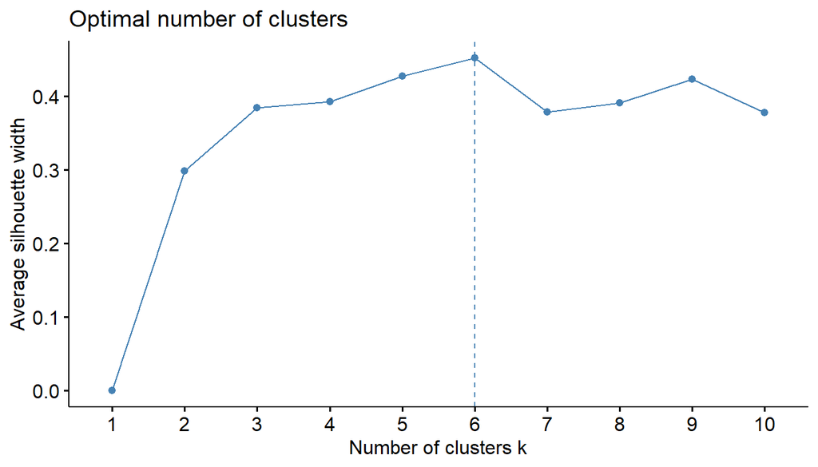

```r
fviz_nbclust(Mall_Customers[,3:5], kmeans, method = "silhouette")
```

## Gap Statistic Method

We can use this method to any of the clustering method like K-means, hierarchical clustering etc. Using the gap statistic, one can compare the total intracluster variation for different values of k along with their expected values under the null reference distribution of data. With the help of Monte Carlo simulations, one can produce the sample dataset. For each variable in the dataset, we can calculate the range between min(xi) and max (xj) through which we can produce values uniformly from interval lower bound to upper bound.

For computing the gap statistics method we can utilize the clusGap function for providing gap statistic as well as standard error for a given output.

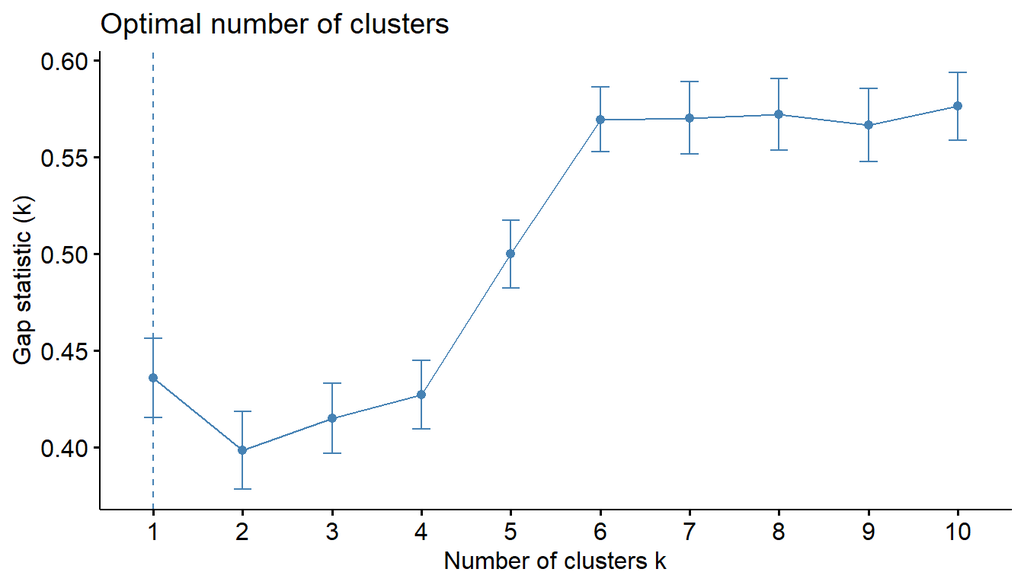

```r
set.seed(125)
stat_gap <- clusGap(Mall_Customers[,3:5], FUN = kmeans, nstart = 25,
            K.max = 10, B = 50)
fviz_gap_stat(stat_gap)
```

Now, let us take k = 6 as our optimal cluster –

```r
k6<-kmeans(Mall_Customers[,3:5],6,iter.max=100,nstart=50,algorithm="Lloyd")
k6
```

```
## K-means clustering with 6 clusters of sizes 45, 21, 35, 39, 38, 22
##
## Cluster means:
##        Age Annual.Income..k.. Spending.Score..1.100.
## 1 56.15556           53.37778               49.08889
## 2 44.14286           25.14286               19.52381
## 3 41.68571           88.22857               17.28571
## 4 32.69231           86.53846               82.12821
## 5 27.00000           56.65789               49.13158
## 6 25.27273           25.72727               79.36364
##
## Clustering vector:
##   [1] 2 6 2 6 2 6 2 6 2 6 2 6 2 6 2 6 2 6 2 6 2 6 2 6 2 6 2 6 2 6 2 6 2 6 2 6 2
##  [38] 6 2 6 1 6 1 5 2 6 1 5 5 5 1 5 5 1 1 1 1 1 5 1 1 5 1 1 1 5 1 1 5 5 1 1 1 1
##  [75] 1 5 1 5 5 1 1 5 1 1 5 1 1 5 5 1 1 5 1 5 5 5 1 5 1 5 5 1 1 5 1 5 1 1 1 1 1
## [112] 5 5 5 5 5 1 1 1 1 5 5 5 4 5 4 3 4 3 4 3 4 5 4 3 4 3 4 3 4 3 4 5 4 3 4 3 4
## [149] 3 4 3 4 3 4 3 4 3 4 3 4 3 4 3 4 3 4 3 4 3 4 3 4 3 4 3 4 3 4 3 4 3 4 3 4 3
## [186] 4 3 4 3 4 3 4 3 4 3 4 3 4 3 4
##
## Within cluster sum of squares by cluster:
## [1]  8062.133  7732.381 16690.857 13972.359  7742.895  4099.818
##  (between_SS / total_SS =  81.1 %)
##
## Available components:
##
## [1] "cluster"      "centers"      "totss"        "withinss"     "tot.withinss"
## [6] "betweenss"    "size"         "iter"         "ifault"
```

In the output of our kmeans operation, we observe a list with several key information. From this, we conclude the useful information being –

cluster – This is a vector of several integers that denote the cluster which has an allocation of each point. totss – This represents the total sum of squares. centers – Matrix comprising of several cluster centers withinss – This is a vector representing the intra-cluster sum of squares having one component per cluster. tot.withinss – This denotes the total intra-cluster sum of squares. betweenss – This is the sum of between-cluster squares. size – The total number of points that each cluster holds.

## Visualizing the Clustering Results using the First Two Principle Components

```r
pcclust=prcomp(Mall_Customers[,3:5],scale=FALSE) #principal component analysis
summary(pcclust)
```

```
## Importance of components:
##                            PC1     PC2     PC3
## Standard deviation     26.4625 26.1597 12.9317
## Proportion of Variance  0.4512  0.4410  0.1078
## Cumulative Proportion   0.4512  0.8922  1.0000
```

```r
pcclust$rotation[,1:2]
```

```
##                               PC1        PC2
## Age                     0.1889742 -0.1309652
## Annual.Income..k..     -0.5886410 -0.8083757
## Spending.Score..1.100. -0.7859965  0.5739136
```

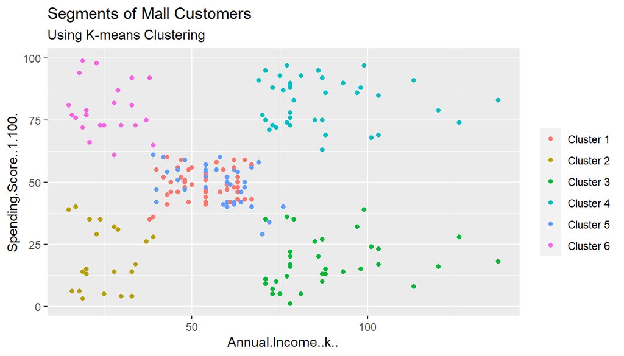

```r
set.seed(1)
ggplot(Mall_Customers, aes(x =Annual.Income..k.., y = Spending.Score..1.100.)) +
  geom_point(stat = "identity", aes(color = as.factor(k6$cluster))) +
  scale_color_discrete(name=" ",
              breaks=c("1", "2", "3", "4", "5","6"),
              labels=c("Cluster 1", "Cluster 2", "Cluster 3", "Cluster 4", "Cluster 5","Cluster 6")) +
  ggtitle("Segments of Mall Customers", subtitle = "Using K-means Clustering")
```

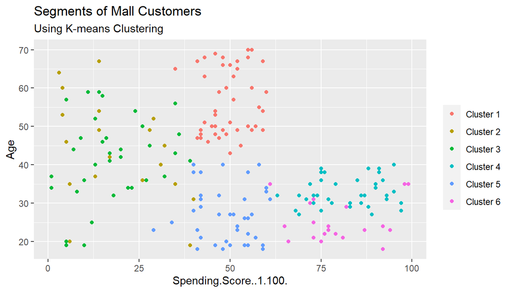

```r
ggplot(Mall_Customers, aes(x =Spending.Score..1.100., y =Age)) +
  geom_point(stat = "identity", aes(color = as.factor(k6$cluster))) +
  scale_color_discrete(name=" ",
                      breaks=c("1", "2", "3", "4", "5","6"),
                      labels=c("Cluster 1", "Cluster 2", "Cluster 3", "Cluster 4", "Cluster 5","Cluster 6")) +
  ggtitle("Segments of Mall Customers", subtitle = "Using K-means Clustering")
```

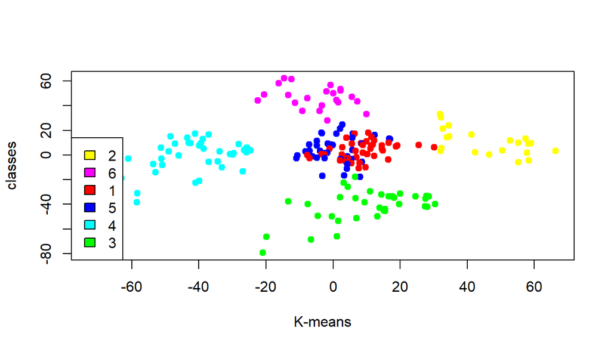

```r
kCols=function(vec){cols=rainbow (length (unique (vec)))
return (cols[as.numeric(as.factor(vec))])}

digCluster<-k6$cluster; dignm<-as.character(digCluster); # K-means clusters

plot(pcclust$x[,1:2], col =kCols(digCluster),pch =19,xlab ="K-means",ylab="classes")
legend("bottomleft",unique(dignm),fill=unique(kCols(digCluster)))
```

With the help of clustering, we can understand the variables much better, prompting us to take careful decisions. With the identification of customers, companies can release products and services that target customers based on several parameters like income, age, spending patterns, etc. Furthermore, more complex patterns like product reviews are taken into consideration for better segmentation.